# Trump Support, Vaccination Rates, and Moving Beyond Correlation to Explanation.

Rex W. Douglass

# Introduction

What explains vaccine uptake across counties in the US? The answer to this question has important implications for understanding and planning for the future course of the pandemic as pockets with low uptake become hotspots for future waves and especially future variants.

# Part 1: Theorizing the Data Generating Process

You may have seen [pairwise correlation plots](https://twitter.com/PollsAndVotes/status/1404667067392053248) that posit a data generating process of uptake like this.

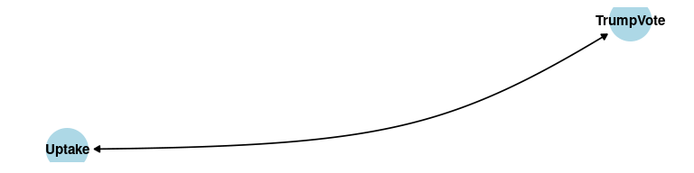

Others have [started to posit](https://tompepinsky.com/2021/06/24/trump-support-and-vaccination-rates-some-hypotheses-and-some-data/) a multivariate data generating process of vaccine uptake that is a linear function of a county’s demographic characteristics, urbanity, and recent presidential vote choices.

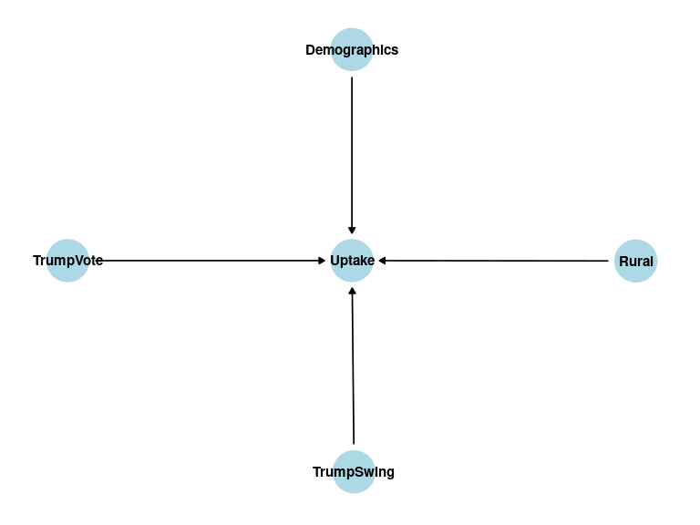

This DGP is better in that it considers additional factors, but it is still an unlikely and incomplete data generating process where TrumpVote is exogenous to demographic and urbanity characteristics of a county. Worse, some of the features are mechanically related to one another, e.g. Log-Population and Rural are included in the same model despite being functions of one another. Likewise TrumpVote and TrumpUpswing are also mechanically related, a county with a 100% swing necessarily has a 100% Trump Vote with a nonlinear function for every other permutation. Drawing the DGP with these additional elements quickly starts to become untenable below.

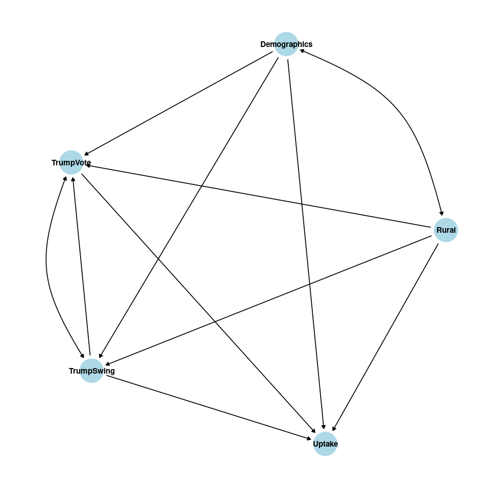

Not to pile on to an already catastrophic causal inference problem, but the course of the pandemic (say in terms of per capita deaths) likely impacted voting decisions and then later vaccine uptake, and education impacted both as well. An example of the kind of graph we could draw including those components is below. In particular, it necessarily includes demographic characteristics like age percentiles because they were an explicit part of the phased Vaccine rollout process and also strongly relate to vote outcomes.

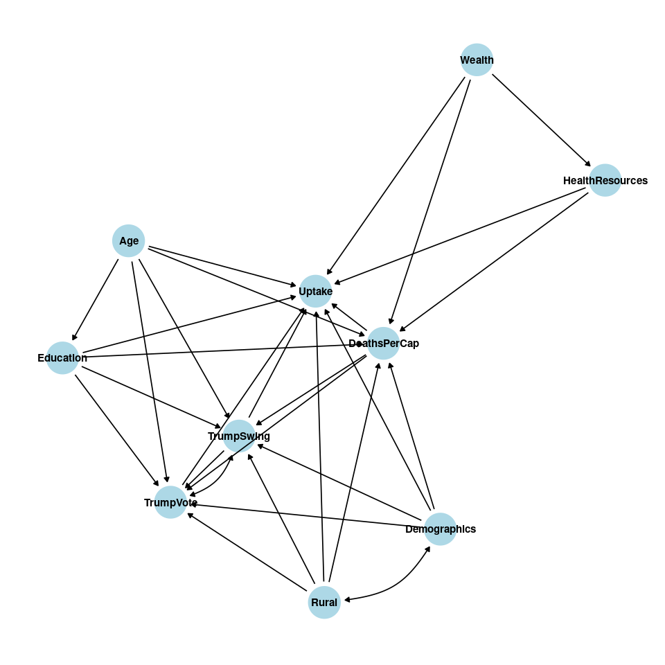

In sum, the simplest toy causal diagram is outside of the reach of a single linear model. Any individual parameter from a model fit to only a subset of these paths is not an estimate of the causal estimand. Further, there are only about 3000 counties worth the datapoints to disentangle this mess, and those counties are auto-correlated in lots of ways not taken into account here which further reduces the unique information available.

# Part 2: Estimating the Data Generating Process

After hopefully discouraging you from interpreting a conditional correlation in a shallow panel dataset as evidence one way or the other of a causal relationship, what ought we do? One alternative is to frame this as a purely observational problem, where our goal is to search across possible data generating processes that could have been behind these observations and then rank them on some measure of performance. The goal is explain variation in an outcome- actually account for variation in vaccine uptake. The claim to validity is that an explanation holds out of domain on new unseen draws, e.g. out of sample on a hold out test or future observations. The importance of any one feature lies only in the unique information that it contributes to solving this task, where features with redundant or unhelpful information are rated lower.

## The Left Hand Side Vaccine Uptake

### CDC County Data

How should we measure vaccine uptake? I being with Tom Pepinsky’s coding decisions in his [blog post](https://tompepinsky.com/2021/06/24/trump-support-and-vaccination-rates-some-hypotheses-and-some-data/) on the topic and his [replicable code repo](https://dataverse.harvard.edu/dataset.xhtml?persistentId=doi:10.7910/DVN/M5BEXF). His outcome is series_complete_18plus_pop_pct which is defined as “Percent of people 18+ who are fully vaccinated (have second dose of a two-dose vaccine or one dose of a single-dose vaccine) based on the jurisdiction and county where recipient lives” compiled by the CDC in the [COVID-19 Vaccinations in the United States,County](https://data.cdc.gov/Vaccinations/COVID-19-Vaccinations-in-the-United-States-County/8xkx-amqh) dataset. The only cleaning performed is to drop 0% and 100% as invalid entries, which I agree with. That leaves observations for 2,946 counties.

The distribution of up Uptake in the country is still abysmal, with the median county at only 41%, and the 3rd quartile barely at 50%.

```
   Min. 1st Qu.  Median    Mean 3rd Qu.    Max.    NA's
 0.0020  0.3370  0.4210  0.4195  0.5180  0.9990     336
```

90% of counties land between 12% and 63%. The measurement task therefore isn’t so much to explain high vaccine uptake from low, but rather to identify stragglers with low uptake form the central mass.

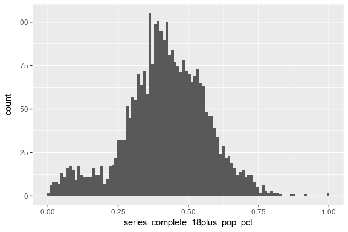

So who are the stragglers? Here’s a map showing the rates in the data. Texas is missing entirely for reporting issues. A few very rural counties are missing as well. The stragglers appear to be concentrated in three states, George, Virginia, and West Virginia and more sporadically across the midwest. Bounding effects that show state are evidence of geogrpahic and administrative auto-correlation, from administration, reporting, or both.

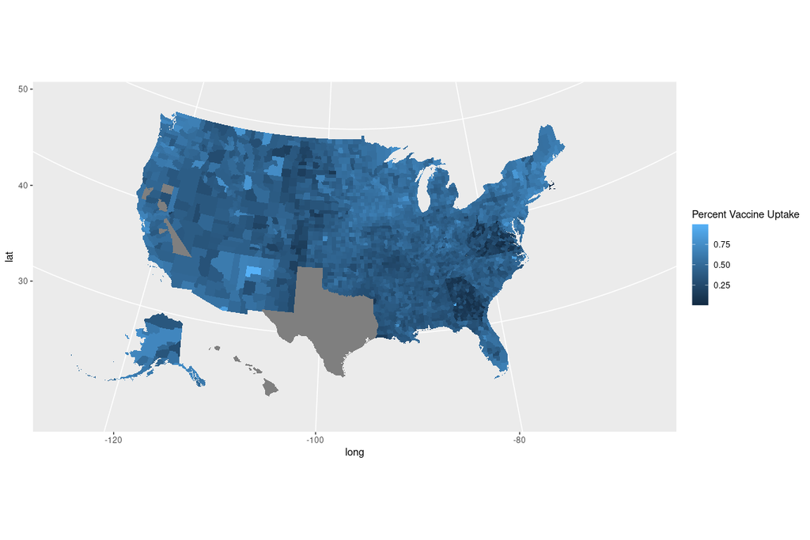

Here is Uptake in tabular format that you can browse in its entirety. Sorted by least Uptake, the top 100 offenders are all VA, WV, GA and one county from MA. The values aren’t just low but near 0, which should set off alarm bells that there might still be measurement processes we haven’t accounted for. In fact, if we look at the [New York Times Vaccine tracker](https://www.nytimes.com/interactive/2020/us/covid-19-vaccine-doses.html), we find that they leave out precisely those three states as “insufficient data.” The [Washington Post’s vaccine tracker](https://www.washingtonpost.com/graphics/2020/health/covid-vaccine-states-distribution-doses/) excludes another three states, New Mexico, Colorado, and South Dakota because less than 85% of vaccination records include a person’s county of residence.

| recip_state | recip_county | fips | series_complete_18plus_pop_pct | series_complete_pop_pct | retrieved |
| --- | --- | --- | --- | --- | --- |
| VA | Danville city | 51590 | 0.002 | 0.001 | 2021-06-25 |
| VA | Martinsville city | 51690 | 0.003 | 0.002 | 2021-06-25 |
| VA | Lynchburg city | 51680 | 0.008 | 0.006 | 2021-06-25 |
| VA | Colonial Heights city | 51570 | 0.008 | 0.006 | 2021-06-25 |
| VA | Galax city | 51640 | 0.008 | 0.006 | 2021-06-25 |
| VA | Waynesboro city | 51820 | 0.01 | 0.008 | 2021-06-25 |
| MA | Nantucket County | 25019 | 0.012 | 0.01 | 2021-06-25 |
| VA | Manassas Park city | 51685 | 0.013 | 0.011 | 2021-06-25 |
| VA | Craig County | 51045 | 0.017 | 0.015 | 2021-06-25 |
| VA | Appomattox County | 51011 | 0.017 | 0.013 | 2021-06-25 |

[output cut: 3272 more lines]

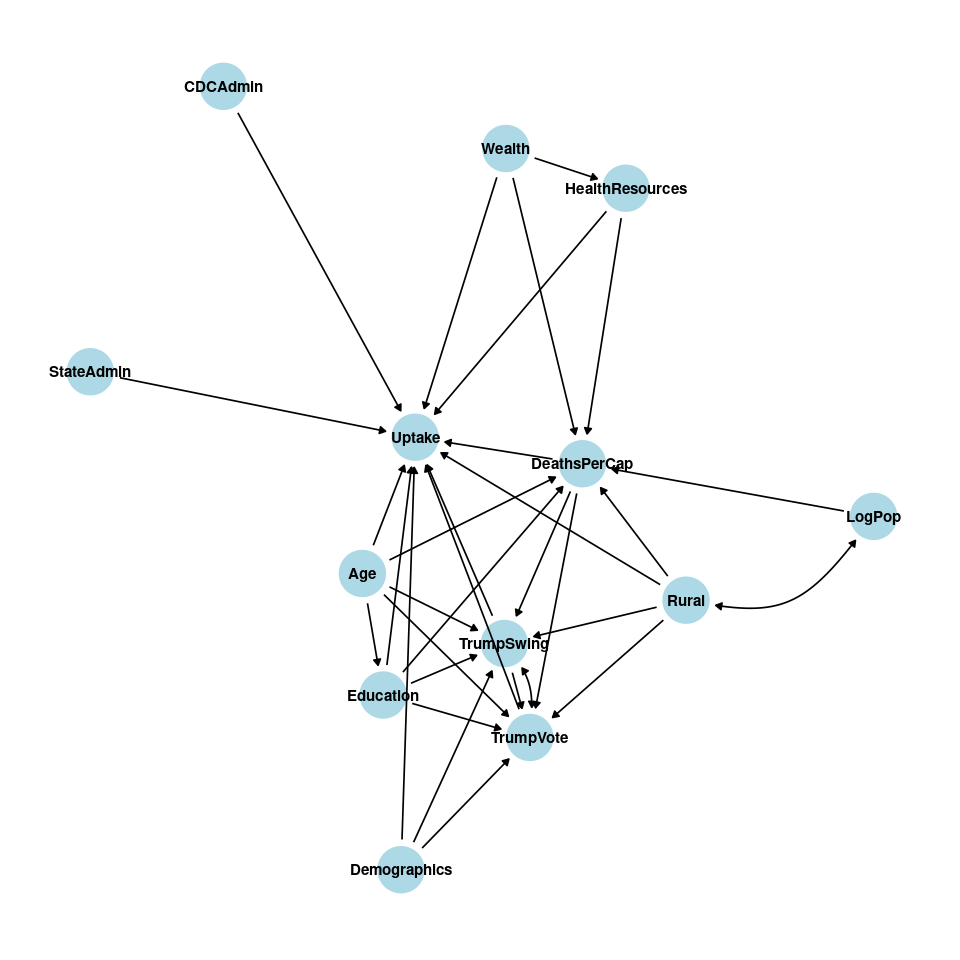

### USA Today Network

The USA Today Network produces databases and visualizations for affiliate, including the [COVID-19 Vaccine Tracker](https://data.democratandchronicle.com/covid-19-vaccine-tracker/). The details of the database are obscure but it pulls CDC data and fills in missing or broken states with data directly from state health agencies. We can pull their numbers for each county and compare them to the CDC counts. Their data cover 3,222 counties.

### CHHS

http://www.vaccinetracking.us/ https://raw.githubusercontent.com/bansallab/vaccinetracking/main/vacc_data/data_master_county.csv

### Compare and Synthesize

Compared to the Democrat and Chronicle data, the CDC systematically under reports vaccinations in VA, GA, NC, etc. The CDC data have higher numbers for PR as well as a few other counties. The Democrat and Chronicle data also have all of Texas.

Comparing Vaccinetracking.us to USA Today finds higher coverage for several counties in MA, WV, and CO.

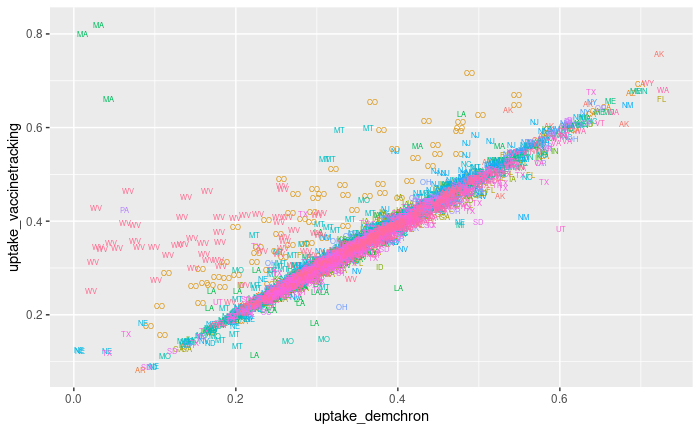

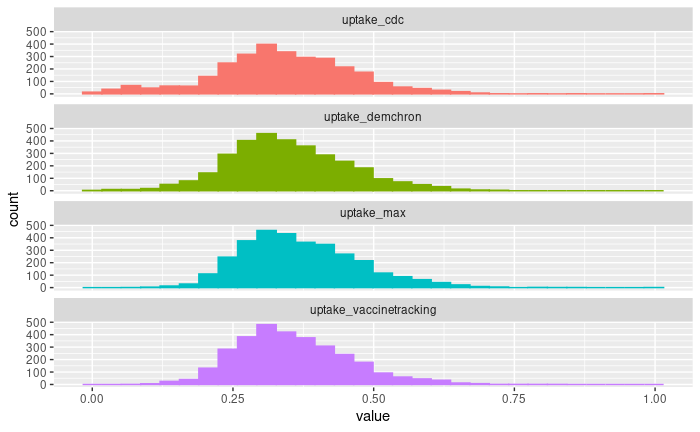

The geographic artifacts have started to disappear and the interesting variation is starting to look like the uptake around the coast and border.

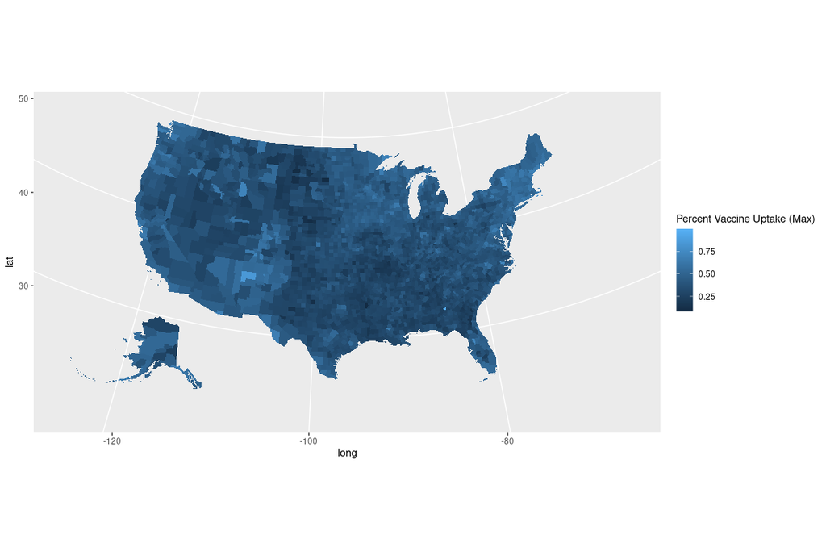

Who are our remaining stragglers? Nantucket County, MA is an island with a population of 11,399. Going to [Massachusetts’s health reports directly](https://www.mass.gov/doc/weekly-covid-19-vaccination-report-june-24-2021/download), finds that it’s actually 81%.

| fips | uptake_demchron | recip_state | recip_county | series_complete_18plus_pop_pct | uptake_cdc | retrieved | uptake_vaccinetracking | uptake_max |
| --- | --- | --- | --- | --- | --- | --- | --- | --- |
| 5091 | 0.0814 | AR | Miller County | 0.107 | 0.083 | 2021-06-25 | 0.0816746422544328 | 0.083 |
| 46089 | 0.0893 | SD | McPherson County | 0.116 | 0.089 | 2021-06-25 | 0.0886927280369903 | 0.0893 |
| 38087 | 0.0966 | ND | Slope County | 0.114 | 0.091 | 2021-06-25 | 0.088 | 0.0966 |
| 31117 | 0.0991 | NE | McPherson County | 0.114 | 0.093 | 2021-06-25 | 0.0910931174089069 | 0.0991 |
| 48269 | 0.0404 | TX | King County |  |  | 2021-06-25 | 0.117647058823529 | 0.117647058823529 |
| 46063 | 0.1213 | SD | Harding County | 0.161 | 0.122 | 2021-06-25 | 0.122496147919877 | 0.122496147919877 |
| 31075 | 0.0072 | NE | Grant County | 0.156 | 0.124 | 2021-06-25 | 0.12199036918138 | 0.124 |
| 31113 | 0.0061 | NE | Logan County | 0.161 | 0.126 | 2021-06-25 | 0.125668449197861 | 0.126 |
| 31005 | 0.0411 | NE | Arthur County | 0.168 | 0.13 | 2021-06-25 | 0.123110151187905 | 0.13 |
| 13049 | 0.1378 | GA | Charlton County | 0.059 | 0.049 | 2021-06-25 | 0.132989844683393 | 0.1378 |

[output cut: 3207 more lines]

## The Training/Validation/Test Split

Given the high degree of spatial and administrative autocorrelation, what would count as independent draws from the same data generating process isn’t clear. At a minimum, we do not want to train on a county and then test on its immediate neighbor because we will attribute high performance to the features in our model even though it’s really some unknown additional local factor that we aren’t including. Since these data are small, we can afford to run many iterations. I propose a 3-fold train/validation/test setup. Using K-means I clustered states into five groups which split the U.S. into three large slices and two distant degenerate folds from Island states/territories which I collapse to the nearest main fols.

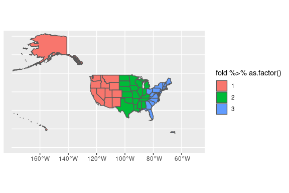

## The Right Hand Side

### Summary Statistics

Data Frame Summary

XYid_all

**Dimensions**: 3217 x 38  
**Duplicates**: 0

| **No** | **Variable** | **Stats / Values** | **Freqs (% of Valid)** | **Graph** | **Missing** |
| --- | --- | --- | --- | --- | --- |
| 1 | fips [numeric] | Mean (sd) : 31434.4 (16300.2) min < med < max: 1001 < 30031 < 72153 IQR (CV) : 27070 (0.5) | 3217 distinct values |  | 0 (0.0%) |
| 2 | uptake_demchron [numeric] | Mean (sd) : 0.3 (0.1) min < med < max: 0 < 0.3 < 0.7 IQR (CV) : 0.1 (0.3) | 2174 distinct values |  | 3 (0.1%) |
| 3 | recip_state [character] | 1. TX 2. GA 3. VA 4. KY 5. MO 6. KS 7. IL 8. NC 9. IA 10. TN [ 42 others ] | 254 ( 7.9% ) 159 ( 4.9% ) 133 ( 4.1% ) 120 ( 3.7% ) 115 ( 3.6% ) 105 ( 3.3% ) 102 ( 3.2% ) 100 ( 3.1% ) 99 ( 3.1% ) 95 ( 3.0% ) 1934 ( 60.1% ) |  | 1 (0.0%) |
| 4 | recip_county [character] | 1. Washington County 2. Jefferson County 3. Franklin County 4. Jackson County 5. Lincoln County 6. Madison County 7. Clay County 8. Montgomery County 9. Marion County 10. Monroe County [ 1941 others ] | 30 ( 0.9% ) 25 ( 0.8% ) 24 ( 0.7% ) 23 ( 0.7% ) 23 ( 0.7% ) 19 ( 0.6% ) 18 ( 0.6% ) 18 ( 0.6% ) 17 ( 0.5% ) 17 ( 0.5% ) 3002 ( 93.3% ) |  | 1 (0.0%) |
| 5 | series_complete_18plus_pop_pct [numeric] | Mean (sd) : 0.4 (0.1) min < med < max: 0 < 0.4 < 1 IQR (CV) : 0.2 (0.4) | 656 distinct values |  | 271 (8.4%) |
| 6 | uptake_cdc [numeric] | Mean (sd) : 0.3 (0.1) min < med < max: 0 < 0.3 < 1 IQR (CV) : 0.2 (0.4) | 579 distinct values |  | 271 (8.4%) |
| 7 | retrieved [Date] | 1. 2021-06-25 | 3216 ( 100.0% ) |  | 1 (0.0%) |
| 8 | uptake_vaccinetracking [numeric] | Mean (sd) : 0.4 (0.1) min < med < max: 0.1 < 0.3 < 0.8 IQR (CV) : 0.1 (0.3) | 3126 distinct values |  | 90 (2.8%) |
| 9 | uptake_max [numeric] | Mean (sd) : 0.4 (0.1) min < med < max: 0.1 < 0.4 < 1 IQR (CV) : 0.1 (0.3) | 2000 distinct values |  | 0 (0.0%) |
| 10 | deaths [integer] | Mean (sd) : 66.6 (268.4) min < med < max: 0 < 12 < 7117 IQR (CV) : 34 (4) | 347 distinct values |  | 92 (2.9%) |
| 11 | rucc_2013 [numeric] | Mean (sd) : 4.9 (2.7) min < med < max: 1 < 6 < 9 IQR (CV) : 5 (0.6) | 1 : 472 ( 14.7% ) 2 : 393 ( 12.2% ) 3 : 367 ( 11.4% ) 4 : 217 ( 6.7% ) 5 : 90 ( 2.8% ) 6 : 597 ( 18.6% ) 7 : 434 ( 13.5% ) 8 : 220 ( 6.8% ) 9 : 425 ( 13.2% ) |  | 2 (0.1%) |
| 12 | tot_pop [integer] | Mean (sd) : 104214.1 (333397.1) min < med < max: 169 < 25673 < 10039107 IQR (CV) : 56795 (3.2) | 3082 distinct values |  | 81 (2.5%) |
| 13 | black_perc [numeric] | Mean (sd) : 10.3 (14.6) min < med < max: 0.3 < 3.5 < 87.2 IQR (CV) : 10.8 (1.4) | 3131 distinct values |  | 81 (2.5%) |
| 14 | native_perc [numeric] | Mean (sd) : 3.3 (8.2) min < med < max: 0.3 < 1.4 < 93.7 IQR (CV) : 1.4 (2.5) | 3133 distinct values |  | 81 (2.5%) |
| 15 | hispanic_perc [numeric] | Mean (sd) : 9.8 (13.9) min < med < max: 0.6 < 4.5 < 96.4 IQR (CV) : 7.7 (1.4) | 3136 distinct values |  | 81 (2.5%) |
| 16 | state_name [character] | 1. Texas 2. Georgia 3. Virginia 4. Kentucky 5. Missouri 6. Kansas 7. Illinois 8. North Carolina 9. Iowa 10. Tennessee [ 40 others ] | 254 ( 8.1% ) 159 ( 5.1% ) 133 ( 4.2% ) 120 ( 3.8% ) 115 ( 3.7% ) 105 ( 3.3% ) 102 ( 3.3% ) 100 ( 3.2% ) 99 ( 3.2% ) 95 ( 3.0% ) 1854 ( 59.1% ) |  | 81 (2.5%) |
| 17 | county_name [character] | 1. Washington County 2. Jefferson County 3. Franklin County 4. Jackson County 5. Lincoln County 6. Madison County 7. Clay County 8. Montgomery County 9. Marion County 10. Monroe County [ 1861 others ] | 30 ( 1.0% ) 25 ( 0.8% ) 24 ( 0.8% ) 23 ( 0.7% ) 23 ( 0.7% ) 19 ( 0.6% ) 18 ( 0.6% ) 18 ( 0.6% ) 17 ( 0.5% ) 17 ( 0.5% ) 2922 ( 93.2% ) |  | 81 (2.5%) |
| 18 | trump_perc [numeric] | Mean (sd) : 66.1 (16.3) min < med < max: 5.5 < 69.5 < 96.9 IQR (CV) : 21.9 (0.2) | 3105 distinct values |  | 109 (3.4%) |
| 19 | romney_perc [numeric] | Mean (sd) : 60.8 (15) min < med < max: 6 < 62.1 < 96.5 IQR (CV) : 20.1 (0.2) | 3107 distinct values |  | 109 (3.4%) |
| 20 | percent_of_adults_with_less_than_a_high_school_diploma_2014_18 [numeric] | Mean (sd) : 13.7 (6.7) min < med < max: 1.2 < 12.3 < 66.3 IQR (CV) : 8.9 (0.5) | 327 distinct values |  | 3 (0.1%) |
| 21 | percent_of_adults_with_a_bachelors_degree_or_higher_2014_18 [numeric] | Mean (sd) : 21.6 (9.4) min < med < max: 0 < 19.3 < 78.5 IQR (CV) : 10.4 (0.4) | 430 distinct values |  | 3 (0.1%) |
| 22 | percent_of_adults_completing_some_college_or_associates_degree_2014_18 [numeric] | Mean (sd) : 30.5 (5.4) min < med < max: 5.8 < 30.5 < 57.3 IQR (CV) : 7.1 (0.2) | 293 distinct values |  | 3 (0.1%) |
| 23 | percent_of_adults_with_a_high_school_diploma_only_2014_18 [numeric] | Mean (sd) : 34.2 (7.2) min < med < max: 5.5 < 34.4 < 55.6 IQR (CV) : 9.5 (0.2) | 368 distinct values |  | 3 (0.1%) |
| 24 | median_household_income_2018 [integer] | Mean (sd) : 52774.9 (13862.7) min < med < max: 25385 < 50564.5 < 140382 IQR (CV) : 15141.8 (0.3) | 3029 distinct values |  | 81 (2.5%) |
| 25 | active_physicians_per_100000_population_2018_aamc [numeric] | Mean (sd) : 254.8 (42.3) min < med < max: 191.3 < 247.1 < 847 IQR (CV) : 51.2 (0.2) | 50 distinct values |  | 81 (2.5%) |
| 26 | unemployment_rate_2018 [numeric] | Mean (sd) : 4.3 (1.9) min < med < max: 1.3 < 3.9 < 18.1 IQR (CV) : 1.7 (0.4) | 130 distinct values |  | 3 (0.1%) |
| 27 | total_hospitals_2019 [numeric] | Mean (sd) : 1.7 (4.3) min < med < max: 0 < 0.5 < 91.7 IQR (CV) : 1.1 (2.6) | 3131 distinct values |  | 81 (2.5%) |
| 28 | area_in_square_miles_land_area [numeric] | Mean (sd) : 1092.4 (3564) min < med < max: 2 < 604.4 < 145504.8 IQR (CV) : 495.4 (3.3) | 3176 distinct values |  | 4 (0.1%) |
| 29 | density_per_square_mile_of_land_area_population [numeric] | Mean (sd) : 283.1 (1723.8) min < med < max: 0 < 46.6 < 69468.4 IQR (CV) : 111.8 (6.1) | 1693 distinct values |  | 4 (0.1%) |
| 30 | population_total [integer] | Mean (sd) : 103870.7 (333421.9) min < med < max: 152 < 25738 < 10105518 IQR (CV) : 56641.8 (3.2) | 3070 distinct values |  | 81 (2.5%) |
| 31 | total_age0to17_perc [numeric] | Mean (sd) : 0.2 (0) min < med < max: 0.1 < 0.2 < 0.4 IQR (CV) : 0 (0.2) | 3134 distinct values |  | 81 (2.5%) |
| 32 | total_age18to64_perc [numeric] | Mean (sd) : 0.6 (0) min < med < max: 0.4 < 0.6 < 0.8 IQR (CV) : 0 (0.1) | 3134 distinct values |  | 81 (2.5%) |
| 33 | total_age65plus_perc [numeric] | Mean (sd) : 0.2 (0) min < med < max: 0 < 0.2 < 0.6 IQR (CV) : 0.1 (0.2) | 3133 distinct values |  | 81 (2.5%) |
| 34 | total_age85plusr_perc [numeric] | Mean (sd) : 0 (0) min < med < max: 0 < 0 < 0.1 IQR (CV) : 0 (0.4) | 3132 distinct values |  | 81 (2.5%) |
| 35 | trump_swing [numeric] | Mean (sd) : 5.3 (6.4) min < med < max: -18.4 < 5.4 < 34.4 IQR (CV) : 8 (1.2) | 3107 distinct values |  | 110 (3.4%) |
| 36 | fips_state [numeric] | Mean (sd) : 31331.4 (16285.6) min < med < max: 1000 < 30000 < 72000 IQR (CV) : 27000 (0.5) | 52 distinct values |  | 0 (0.0%) |
| 37 | fold [numeric] | Mean (sd) : 2.2 (0.6) min < med < max: 1 < 2 < 3 IQR (CV) : 1 (0.3) | 1 : 444 ( 13.8% ) 2 : 1802 ( 56.0% ) 3 : 971 ( 30.2% ) |  | 0 (0.0%) |
| 38 | covid_deaths_percap [numeric] | Mean (sd) : 0 (0) min < med < max: 0 < 0 < 0 IQR (CV) : 0 (1.1) | 2830 distinct values |  | 92 (2.9%) |

Generated by summarytools 0.9.9 ([R](https://www.r-project.org/) version 4.1.0)  
2021-06-25

### Raw Data

Here are the full raw values for the full dataset.

| fips | uptake_demchron | recip_state | recip_county | series_complete_18plus_pop_pct | uptake_cdc | retrieved | uptake_vaccinetracking | uptake_max | deaths | rucc_2013 | tot_pop | black_perc | native_perc | hispanic_perc | state_name | county_name | trump_perc | romney_perc | percent_of_adults_with_less_than_a_high_school_diploma_2014_18 | percent_of_adults_with_a_bachelors_degree_or_higher_2014_18 | percent_of_adults_completing_some_college_or_associates_degree_2014_18 | percent_of_adults_with_a_high_school_diploma_only_2014_18 | median_household_income_2018 | active_physicians_per_100000_population_2018_aamc | unemployment_rate_2018 | total_hospitals_2019 | area_in_square_miles_land_area | density_per_square_mile_of_land_area_population | population_total | … |
| --- | --- | --- | --- | --- | --- | --- | --- | --- | --- | --- | --- | --- | --- | --- | --- | --- | --- | --- | --- | --- | --- | --- | --- | --- | --- | --- | --- | --- | --- | --- |
| 1001 | 0.2459 | AL | Autauga County | 0.31 | 0.243 | 2021-06-25 | 0.241761978914962 | 0.2459 | 31 | 2 | 55869 | 21.0921978199001 | 1.02919329144964 | 2.99092520002148 | Alabama | Autauga County | 72.5576972312644 | 73.199393479909 | 11.3 | 27.7 | 28.4 | 32.6 | 59338 | 217.1 | 3.6 | 1.148905321 | 594.44 | 91.8 | 55601 | … |
| 1003 | 0.3122 | AL | Baldwin County | 0.365 | 0.291 | 2021-06-25 | 0.288446204431225 | 0.3122 | 77 | 3 | 223234 | 9.56574715321143 | 1.61400145139181 | 4.71881523423851 | Alabama | Baldwin County | 77.268271027173 | 78.180956892468 | 9.7 | 31.3 | 31.3 | 27.6 | 57588 | 217.1 | 3.6 | 4.505074295 | 1589.78 | 114.6 | 218022 | … |
| 1005 | 0.2241 | AL | Barbour County | 0.293 | 0.234 | 2021-06-25 | 0.231021631694078 | 0.234 | 9 | 6 | 24686 | 49.0845013367901 | 1.2031110751033 | 4.52483188851981 | Alabama | Barbour County | 53.8608928913585 | 48.420868958297 | 27 | 12.2 | 25.1 | 35.7 | 34382 | 217.1 | 5.2 | 0.514125884 | 884.88 | 31 | 24881 | … |
| 1007 | 0.2014 | AL | Bibb County | 0.252 | 0.203 | 2021-06-25 | 0.189247119764223 | 0.203 | 15 | 1 | 22394 | 21.9121193176744 | 0.924354737876217 | 2.78199517727963 | Alabama | Bibb County | 79.1189149405951 | 73.5781137508999 | 16.8 | 11.5 | 24.4 | 47.3 | 46064 | 217.1 | 4 | 0.462860006 | 622.58 | 36.8 | 22400 | … |
| 1009 | 0.1833 | AL | Blount County | 0.235 | 0.183 | 2021-06-25 | 0.181440874347179 | 0.1833 | 25 | 1 | 57826 | 2.20661985957874 | 1.41804724518383 | 9.65309722270259 | Alabama | Blount County | 90.3477020949874 | 87.4826147426982 | 19.8 | 12.6 | 33.5 | 34 | 50412 | 217.1 | 3.5 | 1.195170658 | 644.78 | 88.9 | 57840 | … |
| 1011 | 0.3138 | AL | Bullock County | 0.404 | 0.322 | 2021-06-25 | 0.320661320661321 | 0.322 | 17 | 6 | 10101 | 70.992970992971 | 1.37610137610138 | 8.55360855360855 | Alabama | Bullock County | 24.9564459930314 | 23.5504518072289 | 24.8 | 13.3 | 22.3 | 39.7 | 29267 | 217.1 | 4.7 | 0.209485479 | 622.8 | 17.5 | 10138 | … |
| 1013 | 0.2412 | AL | Butler County | 0.317 | 0.248 | 2021-06-25 | 0.247171945701357 | 0.248 | 41 | 6 | 19448 | 45.583093377211 | 0.838132455779515 | 1.48601398601399 | Alabama | Butler County | 57.9221054865754 | 53.7681006236127 | 15.4 | 16.1 | 24.6 | 43.9 | 37365 | 217.1 | 4.8 | 0.406655577 | 776.83 | 27 | 19680 | … |
| 1015 | 0.2864 | AL | Calhoun County | 0.366 | 0.29 | 2021-06-25 | 0.28738171735399 | 0.29 | 65 | 3 | 113605 | 22.4312310197615 | 1.20417235156903 | 4.06144095770433 | Alabama | Calhoun County | 69.759723353936 | 66.1250518683527 | 15.9 | 18 | 33.7 | 32.4 | 45400 | 217.1 | 4.7 | 2.361350576 | 605.87 | 195.7 | 114277 | … |
| 1017 | 0.1963 | AL | Chambers County | 0.25 | 0.2 | 2021-06-25 | 0.198682865219222 | 0.2 | 48 | 6 | 33254 | 40.9785288987791 | 0.751789258435075 | 2.6192337763878 | Alabama | Chambers County | 57.8978700886361 | 52.6039870317997 | 18.6 | 13.2 | 29.7 | 38.4 | 39917 | 217.1 | 3.9 | 0.69459996 | 596.53 | 57.4 | 33615 | … |
| 1019 | 0.2207 | AL | Cherokee County | 0.267 | 0.218 | 2021-06-25 | 0.217094212856925 | 0.2207 | 15 | 6 | 26196 | 4.75645136662086 | 1.56130706978165 | 1.71400213773095 | Alabama | Cherokee County | 86.6961579421643 | 77.8792280556132 | 19.8 | 12.9 | 29 | 38.3 | 42132 | 217.1 | 3.6 | 0.53790945 | 553.7 | 46.9 | 26032 | … |

[output cut: 3207 more lines]

# Fit Models

Define some helper functions that will iterate over groups of variables and save predictions.

We devide features into groups: demography, politics, medical, education, and wealth. We then fit models over unique subsets of groups of features, 31 in total.

# Results

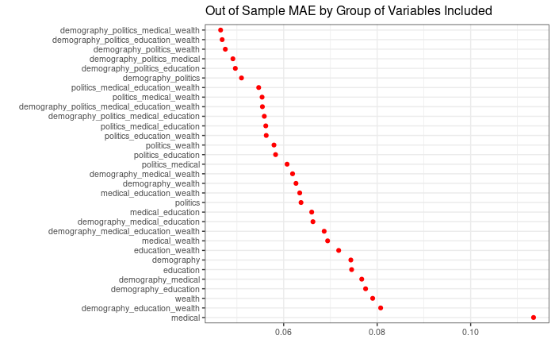

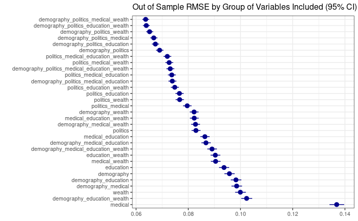